# Does multiple companies involved in the process of TV show making benefit the popularity of a TV show?

Christina Lyu & Sicong Li (using Github[^1])

4/26/2018

On October 30, 2017, after Kevin Spacey, one of the main casts, was accused of making a sexual advance, Netflix announced that the sixth season would be the final season of House of Cards. Originally released in 2013, House of Cards is an American political thriller television series with an average rating of 8.9/10 on IMBD. Although it is marked as Netflix original series, after looking through the production details of it, we found that it gives credits to multiple production companies, including Trigger Street Productions, which produced well-known films like Fifty Shades of Grey and The Social Network in previous years.

Here is a video[^2] of common movie starters which would give credits to multiple companies.

```r
embed_url("https://youtu.be/pK_1ApX_31I")
```

[video not shown]

[Problem Statement] Therefore, we are interested in investigating the relationship between the popularity of TV shows and the number of its production companies: are well-known TV shows always produced by multiple production companies and why.

```r
#The TV shows and the production companies with highest reviews ranked by year with at least 100,000 votes
#used four tables in imdb: movie_info_idx, title, movie_company, company_name
#used index column by using movie_info_idx
tv_rank <- db %>%
  dbGetQuery("SELECT distinct t.id, t.title, n.name,
  mi1.info AS votes, mi2.info AS rating
FROM title t
JOIN movie_info_idx AS mi1 ON mi1.movie_id = t.id
JOIN movie_info_idx AS mi2 ON mi2.movie_id = t.id
join movie_companies as c on c.movie_id = t.id
join company_name as n on n.id = c.company_id
WHERE t.kind_id = 2
#use index column
  AND mi1.info_type_id = 100
  AND mi2.info_type_id = 101
  AND mi1.info > 100000
ORDER BY t.production_year desc;")
tv_rank
```

| id | title | name | votes | rating |
| --- | --- | --- | --- | --- |
| 8753 | 13 Reasons Why | Netflix | 133918 | 8.4 |
| 8753 | 13 Reasons Why | Viacom | 133918 | 8.4 |
| 8753 | 13 Reasons Why | Anonymous Content | 133918 | 8.4 |
| 8753 | 13 Reasons Why | July Moon Productions | 133918 | 8.4 |
| 8753 | 13 Reasons Why | Kicked to the Curb Productions | 133918 | 8.4 |
| 8753 | 13 Reasons Why | Paramount Television | 133918 | 8.4 |
| 2393769 | Stranger Things | Netflix | 355761 | 8.9 |
| 2393769 | Stranger Things | 21 Laps Entertainment | 355761 | 8.9 |
| 2393769 | Stranger Things | Monkey Massacre | 355761 | 8.9 |
| 3074138 | Westworld | DiziMax | 225465 | 9.0 |

[output cut: 2178 more lines]

Firstly, we wanted to analyze ratings among popular TV shows (having over 100,000 votes on IMDB). After a first glance, we noticed an interesting pattern that all of the TV shows shown in our table have multiple rows with the same title, meaning that they have multiple production companies. Since our table is too large to be looked through, we created another table that counts the number of production companies for each of the TV shows.

```r
#TV shows and how many companies were involved in the production in the TV shows with over 100,000 votes
#used four tables: title, movie_info_idx, movie_companies, company_name
#used index column: movie_info_index, and movie_company.company_id column to join it with company_name.id
tv_company <- db %>%
  dbGetQuery("SELECT title, count(distinct name) as companies, avg(mi1.info) as avg_votes, avg(mi2.info) as avg_rating
FROM title t
JOIN movie_info_idx AS mi1 ON mi1.movie_id = t.id
JOIN movie_info_idx AS mi2 ON mi2.movie_id = t.id
JOIN movie_companies as c on c.movie_id = t.id
JOIN company_name as n on n.id = c.company_id
WHERE t.kind_id = 2
  AND mi1.info_type_id = 100
  AND mi2.info_type_id = 101
  AND mi1.info > 100000
GROUP BY title, production_year
ORDER by production_year desc, avg_rating desc")
tv_company
```

| title | companies | avg_votes | avg_rating |
| --- | --- | --- | --- |
| 13 Reasons Why | 6 | 133918 | 8.4 |
| Westworld | 12 | 225465 | 9.0 |
| Stranger Things | 3 | 355761 | 8.9 |
| Narcos | 5 | 216911 | 8.9 |
| Daredevil | 7 | 271060 | 8.7 |
| Better Call Saul | 8 | 200474 | 8.7 |
| Mr. Robot | 17 | 235550 | 8.6 |
| Jessica Jones | 4 | 136919 | 8.2 |
| Fargo | 12 | 221623 | 9.0 |
| True Detective | 15 | 375549 | 9.0 |

[output cut: 89 more lines]

The result, not surprisingly, is consistent with our guess that all of the TV shows with over 100,000 votes are produced by multiple companies. Therefore, we are curious about why a TV show with over 100,000 votes, which indicates that many people have watched it, gives credits to multiple companies.

We came up with several possible explanations. Essentially, multiple roles are involved in the production of a TV show. A distributor or a distribution company, for example, promises the network they will guarantee the episode and at times deficit finance the show’s and is responsible for marketing the TV shows. In exchange, they own the rights to the show and can monetize it after its initial run. Distributors can be different for different countries, and even in the same country for different platforms. Take *13 Reasons Why* as an example, while Netflix is the distributor of video and on the internet in the US in 2017, Viacom owns the right to all media now. A TV show also gives credit to its IP owner: toy companies such as Mattel and Lego, comic book companies such as Marvel, as the sceneries of the show are mainly based on their original stories.

Secondly, companies may choose to collaborate with other firms to minimize risks. Instead of taking a huge gamble by himself or making big bets on high-budget franchise plays, production companies collaborate with other companies to lower risks. A small indie production company may have a good idea, but it needs to seek for financial support to put its idea on screen. In this way, the risk of losing is distributed to several companies, and small to median production companies won’t worry that a single investment failure will lead to bankrupt.

Another reason is that many producers, stars, and writers always have their studios through which they create and make a show. An example will be Brad Pitt and his Plan-B Entertainment, which won the 86th a best-picture Oscar for *12 Years a Slave*. Those people won’t sign on to a show unless their companies are hired. That’s a way to shield some of their payments from taxation, as the money is technically going to the production company, not themselves.

To confirm our guess, we also created a table that counts the number of TV shows that are less popular (having less than 100 votes on IMDb) and the number of their production companies.

```r
#TV shows and how many companies were involved in the production for shows that are not popular
tv_lesspop <- db %>%
  dbGetQuery("SELECT title, count(distinct name) as companies, avg(mi1.info) as avg_votes
FROM title t
JOIN movie_info_idx AS mi1 ON mi1.movie_id = t.id
JOIN movie_companies as c on c.movie_id = t.id
JOIN company_name as n on n.id = c.company_id
WHERE t.kind_id = 2
  AND mi1.info_type_id = 100
  AND mi1.info < 100
GROUP BY title, production_year
ORDER by production_year desc")
tv_lesspop
```

| title | companies | avg_votes |
| --- | --- | --- |
| #hetisingewikkeld | 2 | 30.00000 |
| #Murder | 2 | 10.00000 |
| 1066: A Year to Conquer England | 1 | 81.00000 |
| 171: Negócio de Família | 1 | 7.00000 |
| 20-Se-gi So-nyeon-so-nyeo | 1 | 8.00000 |
| 202 | 1 | 8.00000 |
| 3 Amigonauts | 2 | 6.00000 |
| 30 Youm | 1 | 18.00000 |
| 4Play | 1 | 80.00000 |
| 4x4 Aussie Mates | 1 | 6.00000 |

[output cut: 9990 more lines]

The result verifies our idea as most of the TV shows have only 1 or 2 production companies, as indicated in the companies column.

```r
#TV shows and how many companies were involved in the production for shows that are not popular
tv <- db %>%
  dbGetQuery("SELECT title, count(distinct name) as companies, avg(mi2.info) as avg_rating, production_year
FROM title t
JOIN movie_info_idx as mi2 ON mi2.movie_id = t.id
JOIN movie_companies as c on c.movie_id = t.id
JOIN company_name as n on n.id = c.company_id
WHERE t.kind_id = 2
  AND mi2.info_type_id = 101
GROUP BY title")
```

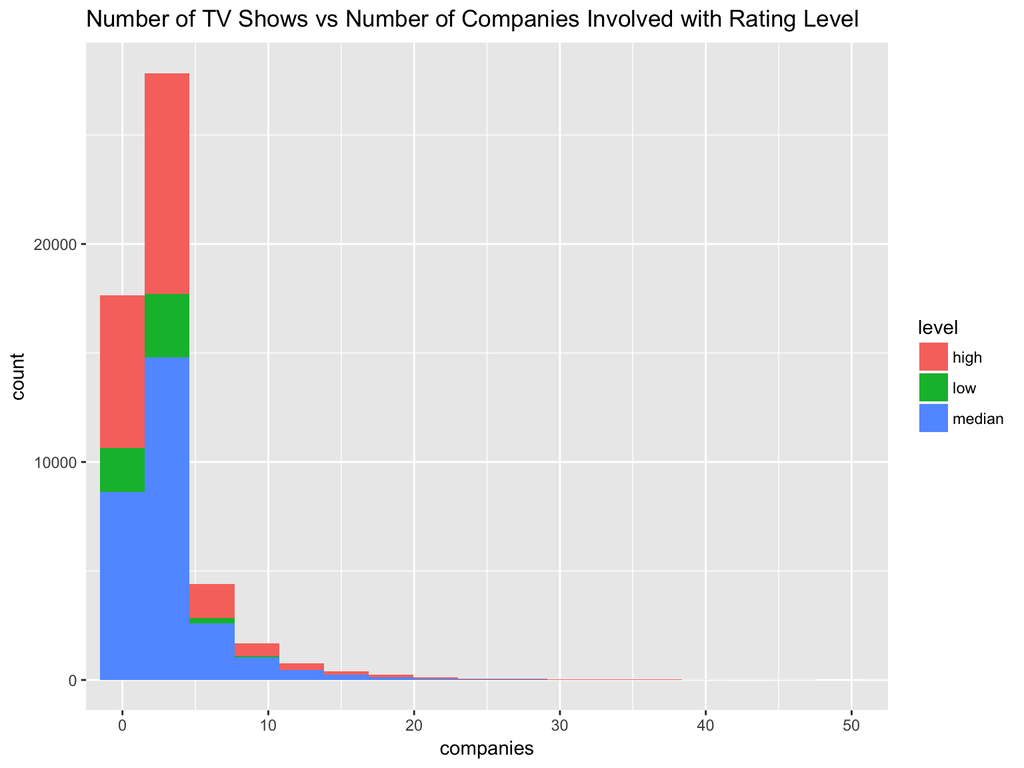

```r
tv_level <-
  tv %>%
  mutate(level = ifelse(avg_rating > 7.5, "high", ifelse(avg_rating < 5, "low", "median")))

tv_level %>%
  ggplot(aes(x = companies, fill = level)) +
  geom_histogram() +
  coord_cartesian(xlim=c(0, 50)) +
  ggtitle("Number of TV Shows vs Number of Companies Involved with Rating Level")
```

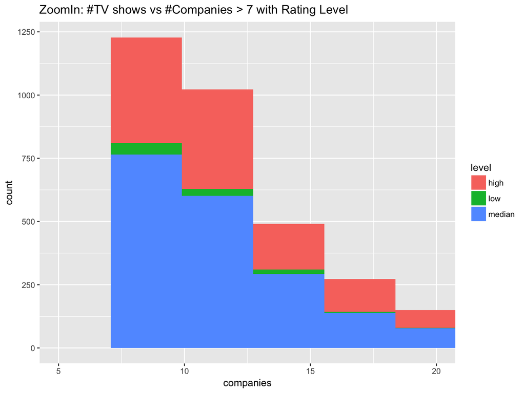

```r
tv_level %>%
  filter(companies > 7) %>%
  ggplot(aes(x = companies, fill = level)) +
  geom_histogram() +
  coord_cartesian(xlim=c(5, 20)) +
  ggtitle("ZoomIn: #TV shows vs #Companies > 7 with Rating Level")
```

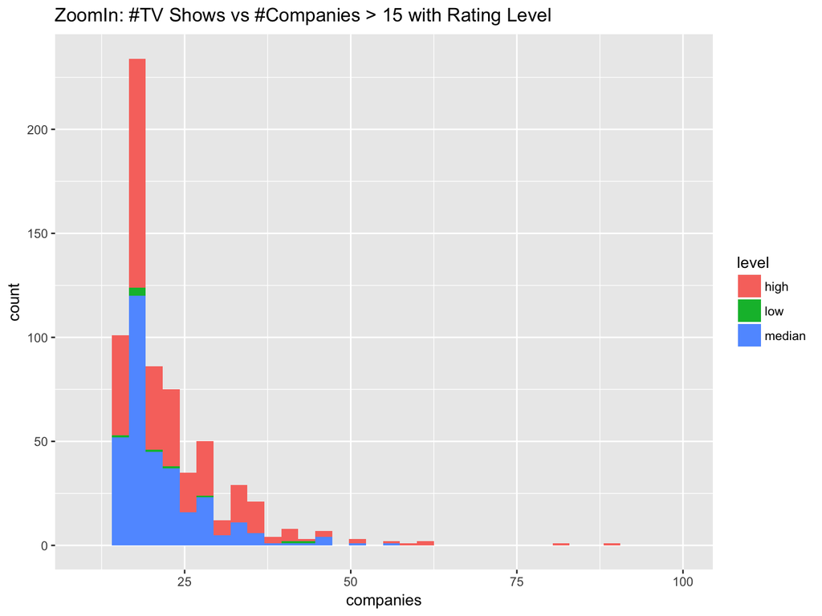

```r
tv_level %>%
  filter(companies > 15) %>%
  ggplot(aes(x = companies, fill = level)) +
  geom_histogram() +
  coord_cartesian(xlim=c(10, 100)) +
  ggtitle("ZoomIn: #TV Shows vs #Companies > 15 with Rating Level")
```

Secondly, we created several histograms to interpret the distribution of the number of companies involved in the production of a TV show. We plotted three levels of rating on the graph. Those with more than 7.5 scores are the level of *high*, 5-7.5 are *median*, and smaller than 5 are *low*. We found that over 80 percent of TV shows are produced by no more than 5 companies, but there are also around 10% of them have very low rating. For those with more than 5 companies involved in the ZoomIn graphs, we can see that the percentage of low rating movies is gradually reduced as the number increases, and becomes unnoticable at the end, as companies will be more cautious about selecting scripts and choosing actors to avoid low quality tv shows. Also music, special effects, and sounds can be improved a lot with more companies involved in, providing larger budgets.

```r
#the percent of top tv shows
top <-
  tv %>%
  mutate(rank = ifelse(avg_rating > 9, 1, 0)) %>%
  group_by(companies) %>%
  summarise(percent = sum(rank == 1) / n()) %>%
  filter(companies < 15)

top
```

| companies | percent |
| --- | --- |
| 1 | 0.015810053 |
| 2 | 0.009997648 |
| 3 | 0.008354219 |
| 4 | 0.005196937 |
| 5 | 0.004337349 |
| 6 | 0.007235890 |
| 7 | 0.006437768 |
| 8 | 0.001479290 |
| 9 | 0.001811594 |
| 10 | 0.004347826 |

[output cut: 4 more lines]

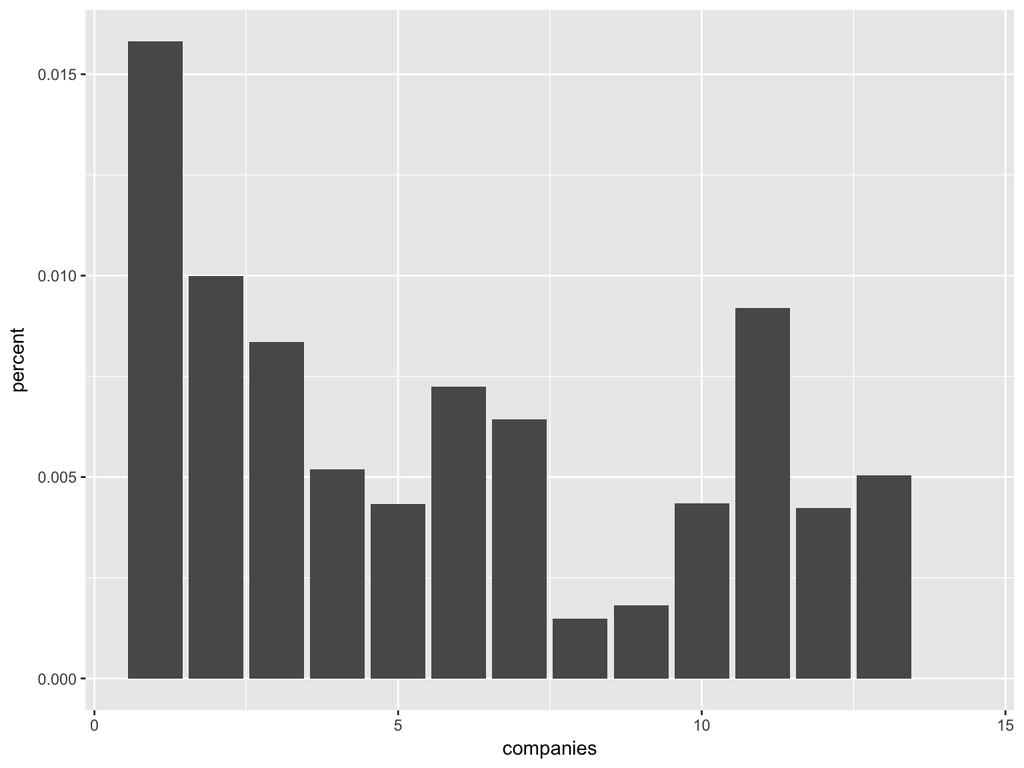

```r
top %>%
  ggplot(aes(x = companies, y = percent)) +
  geom_bar(stat = "identity")
```

As we all know, an independent TV show is usually low in reward, but it’s also low in risk. As a result, the guiding principle is the creation of quality work, with the hope that commercial and critical success will follow. But in the high-stakes game of millions of dollar investment, the principal aim is the return on investment, which means playing it as safe as possible (in both what’s made and how it’s executed), appealing to the widest possible audience, and thus protecting everyone’s investment.

Therefore, it’s custom that multiple companies collaborate in the TV show production, but sometimes bold, single company makes the best show.

[^1]: Github link: https://github.com/ChristinaLyu/miniProject3.git
[^2]: Youtube video link: https://youtu.be/pK_1ApX_31I